# Risk Factor Analysis

## Outcome Variable

**Outcome Variable:** ever_co

## Predictor Variables

**Intervention Variable:** single

**Adjustment Set:**

- arm
- W_mage
- meducyrs
- feducyrs
- W_mhtcm
- W_mwtkg
- W_mbmi
- delta_W_mage
- delta_meducyrs
- delta_feducyrs
- delta_W_mhtcm
- delta_W_mwtkg
- delta_W_mbmi

## Stratifying Variables

The analysis was stratified on these variable(s):

- agecat
- studyid
- country

## Data Summary

| agecat | studyid | country | single | ever_co | n_cell | n |
| --- | --- | --- | --- | --- | --- | --- |
| 0-24 months | COHORTS | GUATEMALA | 0 | 0 | 972 | 1197 |
| 0-24 months | COHORTS | GUATEMALA | 0 | 1 | 127 | 1197 |
| 0-24 months | COHORTS | GUATEMALA | 1 | 0 | 85 | 1197 |
| 0-24 months | COHORTS | GUATEMALA | 1 | 1 | 13 | 1197 |
| 0-24 months | COHORTS | INDIA | 0 | 0 | 4840 | 5374 |
| 0-24 months | COHORTS | INDIA | 0 | 1 | 525 | 5374 |
| 0-24 months | COHORTS | INDIA | 1 | 0 | 7 | 5374 |
| 0-24 months | COHORTS | INDIA | 1 | 1 | 2 | 5374 |
| 0-24 months | COHORTS | PHILIPPINES | 0 | 0 | 2396 | 3005 |
| 0-24 months | COHORTS | PHILIPPINES | 0 | 1 | 535 | 3005 |
| 0-24 months | COHORTS | PHILIPPINES | 1 | 0 | 56 | 3005 |
| 0-24 months | COHORTS | PHILIPPINES | 1 | 1 | 18 | 3005 |
| 0-24 months | Guatemala BSC | GUATEMALA | 0 | 0 | 232 | 282 |
| 0-24 months | Guatemala BSC | GUATEMALA | 0 | 1 | 20 | 282 |
| 0-24 months | Guatemala BSC | GUATEMALA | 1 | 0 | 28 | 282 |
| 0-24 months | Guatemala BSC | GUATEMALA | 1 | 1 | 2 | 282 |
| 0-24 months | JiVitA-4 | BANGLADESH | 0 | 0 | 4540 | 5423 |
| 0-24 months | JiVitA-4 | BANGLADESH | 0 | 1 | 875 | 5423 |
| 0-24 months | JiVitA-4 | BANGLADESH | 1 | 0 | 7 | 5423 |
| 0-24 months | JiVitA-4 | BANGLADESH | 1 | 1 | 1 | 5423 |
| 0-24 months | MAL-ED | BANGLADESH | 0 | 0 | 224 | 263 |
| 0-24 months | MAL-ED | BANGLADESH | 0 | 1 | 39 | 263 |
| 0-24 months | MAL-ED | BANGLADESH | 1 | 0 | 0 | 263 |
| 0-24 months | MAL-ED | BANGLADESH | 1 | 1 | 0 | 263 |
| 0-24 months | MAL-ED | BRAZIL | 0 | 0 | 196 | 233 |
| 0-24 months | MAL-ED | BRAZIL | 0 | 1 | 1 | 233 |
| 0-24 months | MAL-ED | BRAZIL | 1 | 0 | 34 | 233 |
| 0-24 months | MAL-ED | BRAZIL | 1 | 1 | 2 | 233 |
| 0-24 months | MAL-ED | INDIA | 0 | 0 | 196 | 249 |
| 0-24 months | MAL-ED | INDIA | 0 | 1 | 53 | 249 |

[output cut: 150 more lines]

The following strata were considered:

- agecat: 0-24 months, studyid: COHORTS, country: GUATEMALA
- agecat: 0-24 months, studyid: COHORTS, country: INDIA
- agecat: 0-24 months, studyid: COHORTS, country: PHILIPPINES
- agecat: 0-24 months, studyid: Guatemala BSC, country: GUATEMALA
- agecat: 0-24 months, studyid: JiVitA-4, country: BANGLADESH
- agecat: 0-24 months, studyid: MAL-ED, country: BANGLADESH
- agecat: 0-24 months, studyid: MAL-ED, country: BRAZIL
- agecat: 0-24 months, studyid: MAL-ED, country: INDIA
- agecat: 0-24 months, studyid: MAL-ED, country: NEPAL
- agecat: 0-24 months, studyid: MAL-ED, country: PERU
- agecat: 0-24 months, studyid: MAL-ED, country: SOUTH AFRICA
- agecat: 0-24 months, studyid: MAL-ED, country: TANZANIA, UNITED REPUBLIC OF
- agecat: 0-24 months, studyid: PROBIT, country: BELARUS
- agecat: 0-24 months, studyid: TanzaniaChild2, country: TANZANIA, UNITED REPUBLIC OF
- agecat: 0-24 months, studyid: ZVITAMBO, country: ZIMBABWE
- agecat: 0-6 months, studyid: COHORTS, country: GUATEMALA
- agecat: 0-6 months, studyid: COHORTS, country: INDIA
- agecat: 0-6 months, studyid: COHORTS, country: PHILIPPINES
- agecat: 0-6 months, studyid: Guatemala BSC, country: GUATEMALA
- agecat: 0-6 months, studyid: JiVitA-4, country: BANGLADESH
- agecat: 0-6 months, studyid: MAL-ED, country: BANGLADESH
- agecat: 0-6 months, studyid: MAL-ED, country: BRAZIL
- agecat: 0-6 months, studyid: MAL-ED, country: INDIA
- agecat: 0-6 months, studyid: MAL-ED, country: NEPAL
- agecat: 0-6 months, studyid: MAL-ED, country: PERU
- agecat: 0-6 months, studyid: MAL-ED, country: SOUTH AFRICA
- agecat: 0-6 months, studyid: MAL-ED, country: TANZANIA, UNITED REPUBLIC OF
- agecat: 0-6 months, studyid: PROBIT, country: BELARUS
- agecat: 0-6 months, studyid: TanzaniaChild2, country: TANZANIA, UNITED REPUBLIC OF
- agecat: 0-6 months, studyid: ZVITAMBO, country: ZIMBABWE
- agecat: 6-24 months, studyid: COHORTS, country: GUATEMALA
- agecat: 6-24 months, studyid: COHORTS, country: INDIA
- agecat: 6-24 months, studyid: COHORTS, country: PHILIPPINES
- agecat: 6-24 months, studyid: Guatemala BSC, country: GUATEMALA
- agecat: 6-24 months, studyid: JiVitA-4, country: BANGLADESH
- agecat: 6-24 months, studyid: MAL-ED, country: BANGLADESH
- agecat: 6-24 months, studyid: MAL-ED, country: BRAZIL
- agecat: 6-24 months, studyid: MAL-ED, country: INDIA
- agecat: 6-24 months, studyid: MAL-ED, country: NEPAL
- agecat: 6-24 months, studyid: MAL-ED, country: PERU
- agecat: 6-24 months, studyid: MAL-ED, country: SOUTH AFRICA
- agecat: 6-24 months, studyid: MAL-ED, country: TANZANIA, UNITED REPUBLIC OF
- agecat: 6-24 months, studyid: PROBIT, country: BELARUS
- agecat: 6-24 months, studyid: TanzaniaChild2, country: TANZANIA, UNITED REPUBLIC OF
- agecat: 6-24 months, studyid: ZVITAMBO, country: ZIMBABWE

### Dropped Strata

Some strata were dropped due to rare outcomes:

- agecat: 0-24 months, studyid: COHORTS, country: INDIA
- agecat: 0-24 months, studyid: Guatemala BSC, country: GUATEMALA
- agecat: 0-24 months, studyid: JiVitA-4, country: BANGLADESH
- agecat: 0-24 months, studyid: MAL-ED, country: BANGLADESH
- agecat: 0-24 months, studyid: MAL-ED, country: BRAZIL
- agecat: 0-24 months, studyid: MAL-ED, country: INDIA
- agecat: 0-24 months, studyid: MAL-ED, country: NEPAL
- agecat: 0-24 months, studyid: MAL-ED, country: PERU
- agecat: 0-24 months, studyid: MAL-ED, country: TANZANIA, UNITED REPUBLIC OF
- agecat: 0-24 months, studyid: PROBIT, country: BELARUS
- agecat: 0-6 months, studyid: COHORTS, country: GUATEMALA
- agecat: 0-6 months, studyid: COHORTS, country: INDIA
- agecat: 0-6 months, studyid: Guatemala BSC, country: GUATEMALA
- agecat: 0-6 months, studyid: JiVitA-4, country: BANGLADESH
- agecat: 0-6 months, studyid: MAL-ED, country: BANGLADESH
- agecat: 0-6 months, studyid: MAL-ED, country: BRAZIL
- agecat: 0-6 months, studyid: MAL-ED, country: INDIA
- agecat: 0-6 months, studyid: MAL-ED, country: NEPAL
- agecat: 0-6 months, studyid: MAL-ED, country: PERU
- agecat: 0-6 months, studyid: MAL-ED, country: SOUTH AFRICA
- agecat: 0-6 months, studyid: MAL-ED, country: TANZANIA, UNITED REPUBLIC OF
- agecat: 0-6 months, studyid: PROBIT, country: BELARUS
- agecat: 0-6 months, studyid: TanzaniaChild2, country: TANZANIA, UNITED REPUBLIC OF
- agecat: 6-24 months, studyid: COHORTS, country: INDIA
- agecat: 6-24 months, studyid: Guatemala BSC, country: GUATEMALA
- agecat: 6-24 months, studyid: JiVitA-4, country: BANGLADESH
- agecat: 6-24 months, studyid: MAL-ED, country: BANGLADESH
- agecat: 6-24 months, studyid: MAL-ED, country: BRAZIL
- agecat: 6-24 months, studyid: MAL-ED, country: INDIA
- agecat: 6-24 months, studyid: MAL-ED, country: NEPAL
- agecat: 6-24 months, studyid: MAL-ED, country: PERU
- agecat: 6-24 months, studyid: MAL-ED, country: TANZANIA, UNITED REPUBLIC OF
- agecat: 6-24 months, studyid: PROBIT, country: BELARUS

## Methods Detail

We’re interested in the causal parameters $E[Y_a]$ for all values of $a \in \mathcal{A}$. These parameters represent the mean outcome if, possibly contrary to fact, we intervened to set all units to have $A=a$. Under the randomization and positivity assumptions, these are identified by the statistical parameters $\psi_a=E_W[E_{Y|A,W}(Y|A=a,W)]$. In addition, we’re interested in the mean of $Y$, $E[Y]$ under no intervention (the observed mean). We will estimate these parameters by using SuperLearner to fit the relevant likelihood factors – $E_{Y|A,W}(Y|A=a,W)$ and $p(A=a|W)$, and then updating our likelihood fit using a joint TMLE.

For unadjusted analyses ($W=\{\}$), initial likelihoods were estimated using Lrnr_glm to estimate the simple $E(Y|A)$ and Lrnr_mean to estimate $p(A)$. For adjusted analyses, a small library containing Lrnr_glmnet, Lrnr_xgboost, and Lrnr_mean was used.

Having estimated these parameters, we will then use the delta method to estimate relative risks and attributable risks relative to a prespecified baseline level of $A$.

# Results Detail

## Results Plots

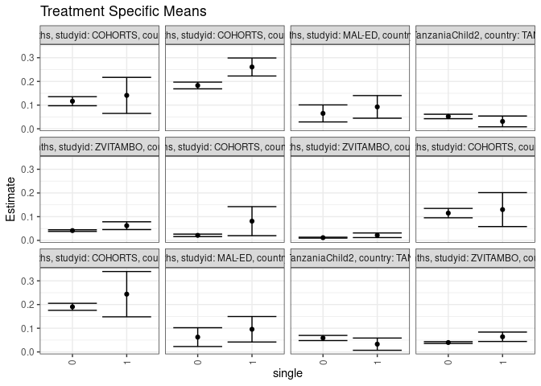

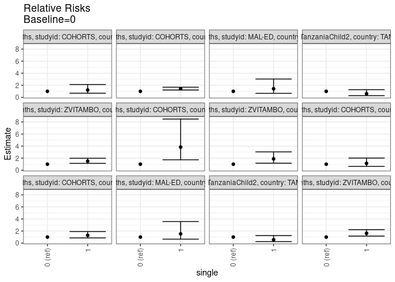

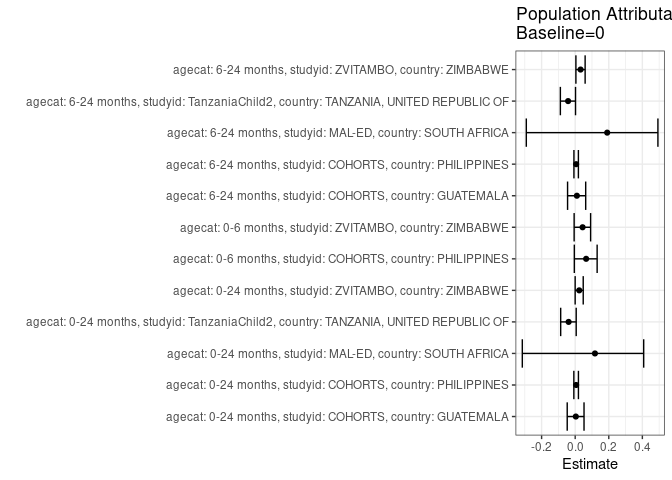

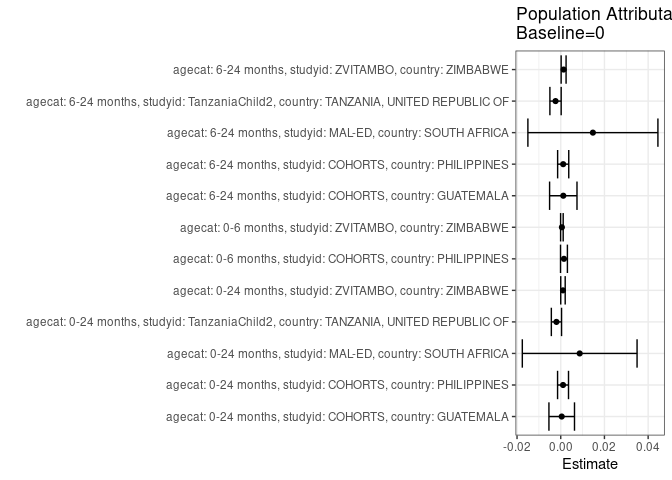

## Results Table

### Parameter: TSM

| agecat | studyid | country | intervention_level | baseline_level | estimate | ci_lower | ci_upper |
| --- | --- | --- | --- | --- | --- | --- | --- |
| 0-24 months | COHORTS | GUATEMALA | 0 | NA | 0.1165126 | 0.0974251 | 0.1356000 |
| 0-24 months | COHORTS | GUATEMALA | 1 | NA | 0.1410632 | 0.0650019 | 0.2171245 |
| 0-24 months | COHORTS | PHILIPPINES | 0 | NA | 0.1829732 | 0.1687494 | 0.1971969 |
| 0-24 months | COHORTS | PHILIPPINES | 1 | NA | 0.2608924 | 0.2229407 | 0.2988441 |
| 0-24 months | MAL-ED | SOUTH AFRICA | 0 | NA | 0.0650453 | 0.0290552 | 0.1010353 |
| 0-24 months | MAL-ED | SOUTH AFRICA | 1 | NA | 0.0925480 | 0.0447215 | 0.1403745 |
| 0-24 months | TanzaniaChild2 | TANZANIA, UNITED REPUBLIC OF | 0 | NA | 0.0520688 | 0.0426781 | 0.0614595 |
| 0-24 months | TanzaniaChild2 | TANZANIA, UNITED REPUBLIC OF | 1 | NA | 0.0312500 | 0.0084599 | 0.0540401 |
| 0-24 months | ZVITAMBO | ZIMBABWE | 0 | NA | 0.0412542 | 0.0378286 | 0.0446797 |
| 0-24 months | ZVITAMBO | ZIMBABWE | 1 | NA | 0.0619847 | 0.0455762 | 0.0783932 |
| 0-6 months | COHORTS | PHILIPPINES | 0 | NA | 0.0211604 | 0.0159465 | 0.0263744 |
| 0-6 months | COHORTS | PHILIPPINES | 1 | NA | 0.0810811 | 0.0197904 | 0.1423718 |
| 0-6 months | ZVITAMBO | ZIMBABWE | 0 | NA | 0.0114381 | 0.0096045 | 0.0132718 |
| 0-6 months | ZVITAMBO | ZIMBABWE | 1 | NA | 0.0215753 | 0.0118543 | 0.0312962 |
| 6-24 months | COHORTS | GUATEMALA | 0 | NA | 0.1150481 | 0.0953161 | 0.1347802 |
| 6-24 months | COHORTS | GUATEMALA | 1 | NA | 0.1299572 | 0.0582621 | 0.2016523 |
| 6-24 months | COHORTS | PHILIPPINES | 0 | NA | 0.1902991 | 0.1754856 | 0.2051127 |
| 6-24 months | COHORTS | PHILIPPINES | 1 | NA | 0.2437592 | 0.1482064 | 0.3393119 |
| 6-24 months | MAL-ED | SOUTH AFRICA | 0 | NA | 0.0625000 | 0.0228875 | 0.1021125 |
| 6-24 months | MAL-ED | SOUTH AFRICA | 1 | NA | 0.0956522 | 0.0417937 | 0.1495107 |
| 6-24 months | TanzaniaChild2 | TANZANIA, UNITED REPUBLIC OF | 0 | NA | 0.0588235 | 0.0480079 | 0.0696391 |
| 6-24 months | TanzaniaChild2 | TANZANIA, UNITED REPUBLIC OF | 1 | NA | 0.0327869 | 0.0069796 | 0.0585942 |
| 6-24 months | ZVITAMBO | ZIMBABWE | 0 | NA | 0.0396368 | 0.0358291 | 0.0434445 |
| 6-24 months | ZVITAMBO | ZIMBABWE | 1 | NA | 0.0639653 | 0.0441401 | 0.0837904 |

### Parameter: E(Y)

| agecat | studyid | country | intervention_level | baseline_level | estimate | ci_lower | ci_upper |
| --- | --- | --- | --- | --- | --- | --- | --- |
| 0-24 months | COHORTS | GUATEMALA | NA | NA | 0.1169591 | 0.0987457 | 0.1351724 |
| 0-24 months | COHORTS | PHILIPPINES | NA | NA | 0.1840266 | 0.1701694 | 0.1978839 |
| 0-24 months | MAL-ED | SOUTH AFRICA | NA | NA | 0.0737179 | 0.0446760 | 0.1027599 |
| 0-24 months | TanzaniaChild2 | TANZANIA, UNITED REPUBLIC OF | NA | NA | 0.0501053 | 0.0413295 | 0.0588811 |
| 0-24 months | ZVITAMBO | ZIMBABWE | NA | NA | 0.0422728 | 0.0389260 | 0.0456196 |
| 0-6 months | COHORTS | PHILIPPINES | NA | NA | 0.0226365 | 0.0173166 | 0.0279564 |
| 0-6 months | ZVITAMBO | ZIMBABWE | NA | NA | 0.0119652 | 0.0101504 | 0.0137800 |
| 6-24 months | COHORTS | GUATEMALA | NA | NA | 0.1162162 | 0.0973542 | 0.1350783 |
| 6-24 months | COHORTS | PHILIPPINES | NA | NA | 0.1914203 | 0.1767774 | 0.2060633 |
| 6-24 months | MAL-ED | SOUTH AFRICA | NA | NA | 0.0772201 | 0.0446475 | 0.1097927 |
| 6-24 months | TanzaniaChild2 | TANZANIA, UNITED REPUBLIC OF | NA | NA | 0.0564436 | 0.0463321 | 0.0665551 |
| 6-24 months | ZVITAMBO | ZIMBABWE | NA | NA | 0.0409509 | 0.0372078 | 0.0446940 |

### Parameter: RR

| agecat | studyid | country | intervention_level | baseline_level | estimate | ci_lower | ci_upper |
| --- | --- | --- | --- | --- | --- | --- | --- |
| 0-24 months | COHORTS | GUATEMALA | 0 | 0 | 1.0000000 | 1.0000000 | 1.000000 |
| 0-24 months | COHORTS | GUATEMALA | 1 | 0 | 1.2107122 | 0.6890262 | 2.127385 |
| 0-24 months | COHORTS | PHILIPPINES | 0 | 0 | 1.0000000 | 1.0000000 | 1.000000 |
| 0-24 months | COHORTS | PHILIPPINES | 1 | 0 | 1.4258504 | 1.2097905 | 1.680497 |
| 0-24 months | MAL-ED | SOUTH AFRICA | 0 | 0 | 1.0000000 | 1.0000000 | 1.000000 |
| 0-24 months | MAL-ED | SOUTH AFRICA | 1 | 0 | 1.4228246 | 0.6664198 | 3.037770 |
| 0-24 months | TanzaniaChild2 | TANZANIA, UNITED REPUBLIC OF | 0 | 0 | 1.0000000 | 1.0000000 | 1.000000 |
| 0-24 months | TanzaniaChild2 | TANZANIA, UNITED REPUBLIC OF | 1 | 0 | 0.6001674 | 0.2831440 | 1.272147 |
| 0-24 months | ZVITAMBO | ZIMBABWE | 0 | 0 | 1.0000000 | 1.0000000 | 1.000000 |
| 0-24 months | ZVITAMBO | ZIMBABWE | 1 | 0 | 1.5025086 | 1.1389294 | 1.982153 |
| 0-6 months | COHORTS | PHILIPPINES | 0 | 0 | 1.0000000 | 1.0000000 | 1.000000 |
| 0-6 months | COHORTS | PHILIPPINES | 1 | 0 | 3.8317350 | 1.7302287 | 8.485695 |
| 0-6 months | ZVITAMBO | ZIMBABWE | 0 | 0 | 1.0000000 | 1.0000000 | 1.000000 |
| 0-6 months | ZVITAMBO | ZIMBABWE | 1 | 0 | 1.8862581 | 1.1693033 | 3.042812 |
| 6-24 months | COHORTS | GUATEMALA | 0 | 0 | 1.0000000 | 1.0000000 | 1.000000 |
| 6-24 months | COHORTS | GUATEMALA | 1 | 0 | 1.1295897 | 0.6339216 | 2.012824 |
| 6-24 months | COHORTS | PHILIPPINES | 0 | 0 | 1.0000000 | 1.0000000 | 1.000000 |
| 6-24 months | COHORTS | PHILIPPINES | 1 | 0 | 1.2809262 | 0.8593951 | 1.909217 |
| 6-24 months | MAL-ED | SOUTH AFRICA | 0 | 0 | 1.0000000 | 1.0000000 | 1.000000 |
| 6-24 months | MAL-ED | SOUTH AFRICA | 1 | 0 | 1.5304348 | 0.6555784 | 3.572770 |
| 6-24 months | TanzaniaChild2 | TANZANIA, UNITED REPUBLIC OF | 0 | 0 | 1.0000000 | 1.0000000 | 1.000000 |
| 6-24 months | TanzaniaChild2 | TANZANIA, UNITED REPUBLIC OF | 1 | 0 | 0.5573770 | 0.2483727 | 1.250819 |
| 6-24 months | ZVITAMBO | ZIMBABWE | 0 | 0 | 1.0000000 | 1.0000000 | 1.000000 |
| 6-24 months | ZVITAMBO | ZIMBABWE | 1 | 0 | 1.6137845 | 1.1667892 | 2.232023 |

### Parameter: PAR

| agecat | studyid | country | intervention_level | baseline_level | estimate | ci_lower | ci_upper |
| --- | --- | --- | --- | --- | --- | --- | --- |
| 0-24 months | COHORTS | GUATEMALA | 0 | NA | 0.0004465 | -0.0054038 | 0.0062968 |
| 0-24 months | COHORTS | PHILIPPINES | 0 | NA | 0.0010534 | -0.0014505 | 0.0035574 |
| 0-24 months | MAL-ED | SOUTH AFRICA | 0 | NA | 0.0086727 | -0.0175858 | 0.0349311 |
| 0-24 months | TanzaniaChild2 | TANZANIA, UNITED REPUBLIC OF | 0 | NA | -0.0019635 | -0.0043012 | 0.0003741 |
| 0-24 months | ZVITAMBO | ZIMBABWE | 0 | NA | 0.0010186 | 0.0000002 | 0.0020370 |
| 0-6 months | COHORTS | PHILIPPINES | 0 | NA | 0.0014761 | -0.0000972 | 0.0030493 |
| 0-6 months | ZVITAMBO | ZIMBABWE | 0 | NA | 0.0005271 | -0.0000651 | 0.0011192 |
| 6-24 months | COHORTS | GUATEMALA | 0 | NA | 0.0011681 | -0.0051002 | 0.0074364 |
| 6-24 months | COHORTS | PHILIPPINES | 0 | NA | 0.0011212 | -0.0014238 | 0.0036662 |
| 6-24 months | MAL-ED | SOUTH AFRICA | 0 | NA | 0.0147201 | -0.0150335 | 0.0444737 |
| 6-24 months | TanzaniaChild2 | TANZANIA, UNITED REPUBLIC OF | 0 | NA | -0.0023800 | -0.0049588 | 0.0001989 |
| 6-24 months | ZVITAMBO | ZIMBABWE | 0 | NA | 0.0013141 | 0.0001839 | 0.0024442 |

### Parameter: PAF

| agecat | studyid | country | intervention_level | baseline_level | estimate | ci_lower | ci_upper |
| --- | --- | --- | --- | --- | --- | --- | --- |
| 0-24 months | COHORTS | GUATEMALA | 0 | NA | 0.0038176 | -0.0474786 | 0.0526017 |
| 0-24 months | COHORTS | PHILIPPINES | 0 | NA | 0.0057244 | -0.0080077 | 0.0192695 |
| 0-24 months | MAL-ED | SOUTH AFRICA | 0 | NA | 0.1176468 | -0.3148675 | 0.4078893 |
| 0-24 months | TanzaniaChild2 | TANZANIA, UNITED REPUBLIC OF | 0 | NA | -0.0391883 | -0.0864337 | 0.0060025 |
| 0-24 months | ZVITAMBO | ZIMBABWE | 0 | NA | 0.0240967 | -0.0002272 | 0.0478291 |
| 0-6 months | COHORTS | PHILIPPINES | 0 | NA | 0.0652078 | -0.0052026 | 0.1306862 |
| 0-6 months | ZVITAMBO | ZIMBABWE | 0 | NA | 0.0440497 | -0.0062954 | 0.0918761 |
| 6-24 months | COHORTS | GUATEMALA | 0 | NA | 0.0100510 | -0.0453663 | 0.0625305 |
| 6-24 months | COHORTS | PHILIPPINES | 0 | NA | 0.0058572 | -0.0075262 | 0.0190629 |
| 6-24 months | MAL-ED | SOUTH AFRICA | 0 | NA | 0.1906250 | -0.2911290 | 0.4926240 |
| 6-24 months | TanzaniaChild2 | TANZANIA, UNITED REPUBLIC OF | 0 | NA | -0.0421655 | -0.0882963 | 0.0020098 |
| 6-24 months | ZVITAMBO | ZIMBABWE | 0 | NA | 0.0320889 | 0.0042162 | 0.0591815 |